# Preliminary results of Better Bee Biology literature scraping

Compiled by John M. Mola

Updated: August 12, 2020

```r
df_b3 <- read_rds("../data/data_output/literature-review-combined-downloaded-2020-07-31.RDS")
```

```r
# excludes papers that were not reviewed (likely because they couldn't be found) by removing ones with "NA" in the "relevant" column
df_completed <- df_b3 %>%
  filter(!is.na(relevant))

# only the relevant papers
df_relevant <- df_completed %>%
  filter(relevant == "yes")
```

## 1. Categories of the reviewed papers

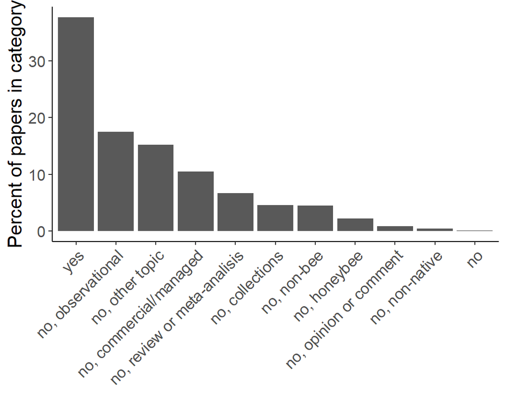

```r
df_completed %>%
  group_by(relevant) %>%
  tally() %>%
  #group_by(gathered_by) %>%
  mutate(total_reviewed = sum(n), percent_category = n/total_reviewed) %>%
  ggplot(., aes(x = reorder(relevant, -percent_category), y = percent_category*100)) +
  geom_bar(stat = "identity") +
  #facet_wrap(~gathered_by) +
  # theme_bw() +
  theme(axis.text.x = element_text(angle = 45, hjust = 1)) +
  labs(x = "", y = "Percent of papers in category")
```

## 2A. Bees captured across different capture methods

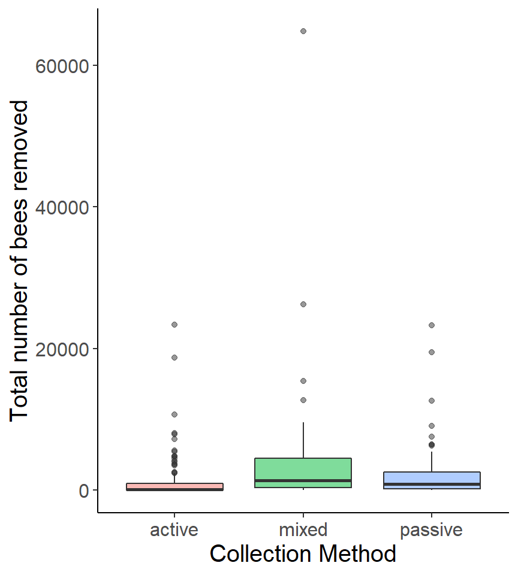

```r
df_relevant %>%
  filter(!is.na(collection_method), confidence_n_bees == "certain") %>%
  ggplot(., aes(x = collection_method, y = n_bees_removed, fill = collection_method)) +
  #geom_jitter(width = 0.1, size = 2, alpha = 0.5, aes(color = confidence_n_bees)) +
  geom_boxplot(alpha = 0.5) +
  theme(legend.position = "none") +
  labs(x = "Collection Method", y = "Total number of bees removed")
```

## 2B. Same as above, outliers excluded, zoomed in.

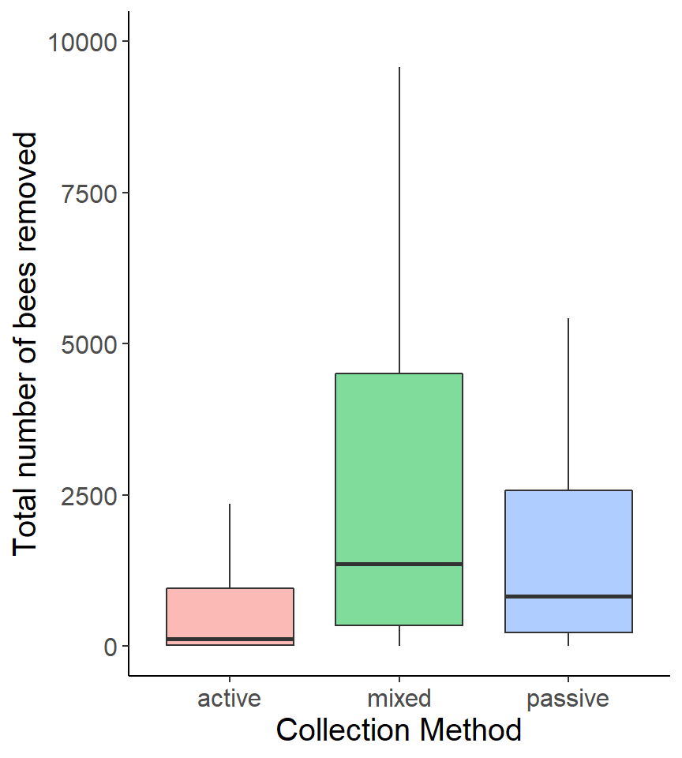

```r
df_relevant %>%
  filter(!is.na(collection_method), confidence_n_bees == "certain") %>%
  ggplot(., aes(x = collection_method, y = n_bees_removed, fill = collection_method)) +
  #geom_jitter(width = 0.1, size = 2, alpha = 0.5, aes(color = confidence_n_bees)) +
  geom_boxplot(alpha = 0.5, outlier.shape = NA) +
  theme(legend.position = "none") +
  labs(x = "Collection Method", y = "Total number of bees removed") +
  coord_cartesian(ylim = c(0, 10000))
```

## 3. Percent reporting museum deposition info

**NB** This is silly as a figure, but I didn’t want to do text here. In a manuscript probably much easier to just state it. Or have it as a small inset figure within a larger display item…

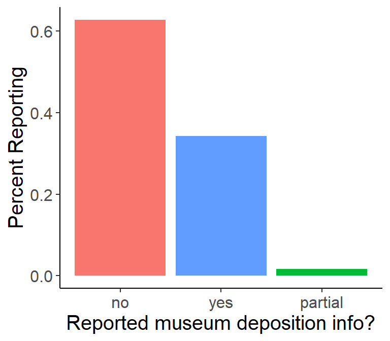

```r
df_relevant %>%
  group_by(deposition_info) %>%
  tally() %>%
  mutate(percent_reporting = n/sum(n)) %>%
  filter(!is.na(deposition_info)) %>%
  ggplot(., aes(x = reorder(deposition_info, -n), y = percent_reporting, fill = deposition_info)) +
  geom_bar(stat = "identity") +
  theme(legend.position = "none") +
  labs(x = "Reported museum deposition info?", y = "Percent Reporting")
```

## 4. Percent reporting deposition info across years

**NB** The earliest years have very few papers, so ~60% reporting might just be 3 out of 5 papers or something.

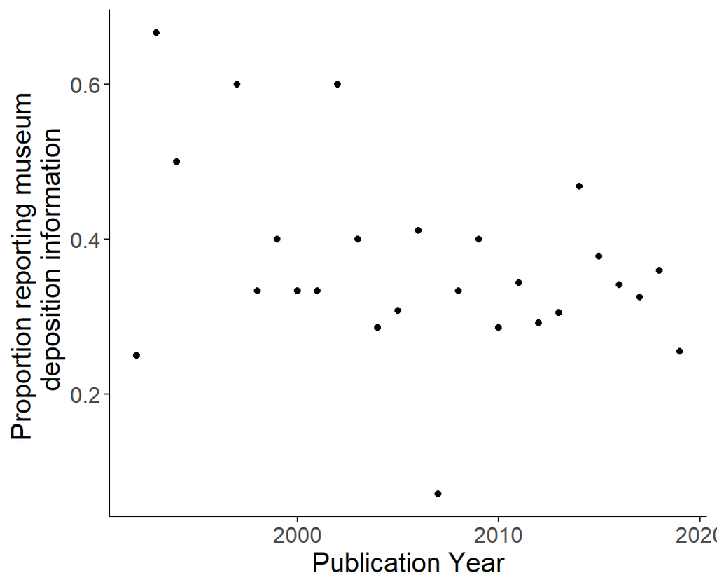

```r
df_relevant %>%
  group_by(deposition_info, PY) %>%
  tally() %>%
  group_by(PY) %>%
  mutate(year_pubs = sum(n)) %>%
  filter(deposition_info == "yes") %>%
  mutate(percent_reporting = n/year_pubs) %>%
  ggplot(., aes(x = PY, y = percent_reporting)) +
  geom_point() +
  labs(x = "Publication Year", y= "Proportion reporting museum \n deposition information")
```

## 5. Bees removed across time

**NB** Only includes studies that reported collection method and we were confident in the number removed. Includes a LOESS smooth because why not? For what it’s worth, the result looks basically the same when you calculate study duration using first/last year, but this requires fewer assumptions.

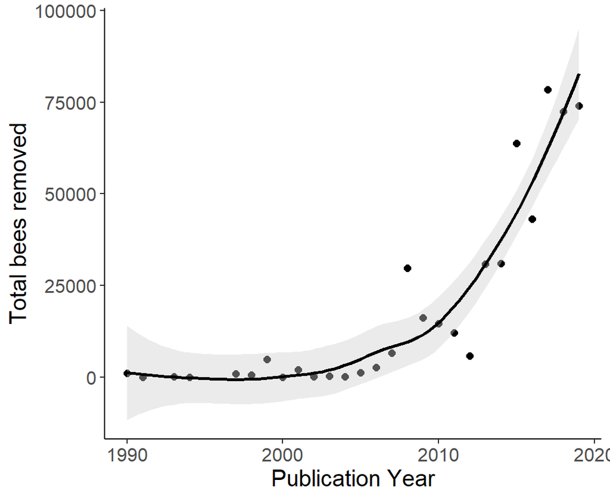

```r
df_relevant %>%
  filter(!is.na(collection_method), confidence_n_bees == "certain") %>%
  # mutate(study_duration = (last_year - first_year)+1, bees_per_year = n_bees_removed/study_duration) %>%
  group_by(PY) %>%
  summarise(total_bees_py = sum(n_bees_removed, na.rm = T)) %>%
  ggplot(., aes(x = PY, y = total_bees_py)) +
  geom_point(size = 2) +
  geom_smooth(color = "black", fill = "grey80") +
  labs(y = "Total bees removed", x = "Publication Year")
```

## 6. Collection methods through time

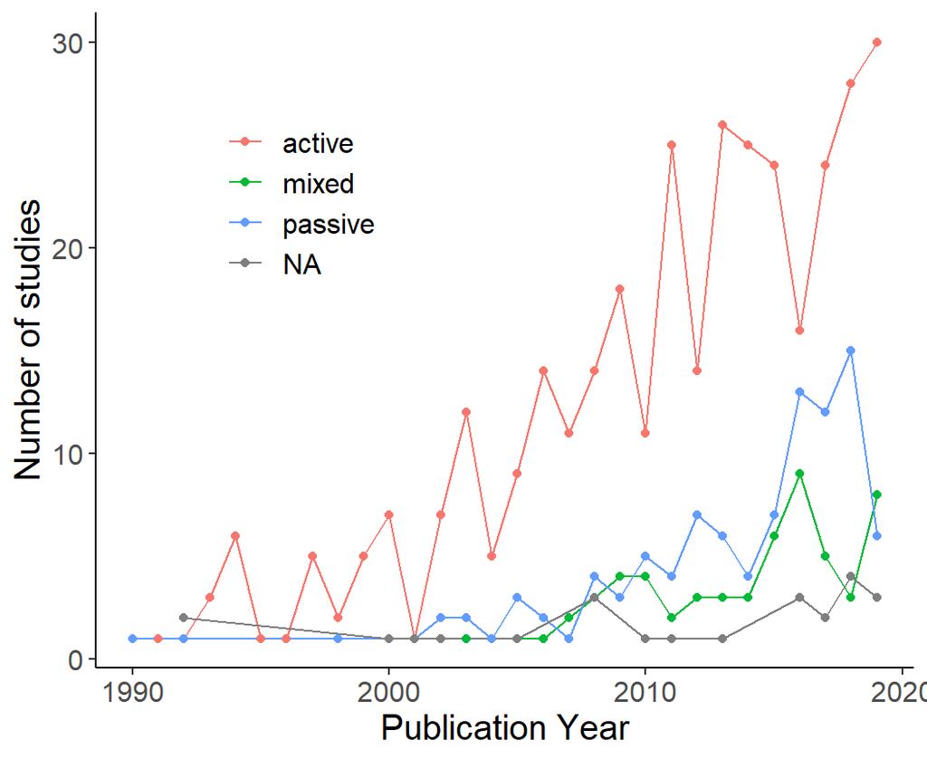

```r
df_relevant %>%
  group_by(PY, collection_method) %>%
  tally() %>%
  ggplot(., aes(x = PY, y = n, color = collection_method)) +
  geom_path() +
  geom_point() +
  labs(x = "Publication Year", y = "Number of studies", color = "") +
  theme(legend.position = c(0.25, 0.75))
```

## 7. No relationship between study duration and publication year

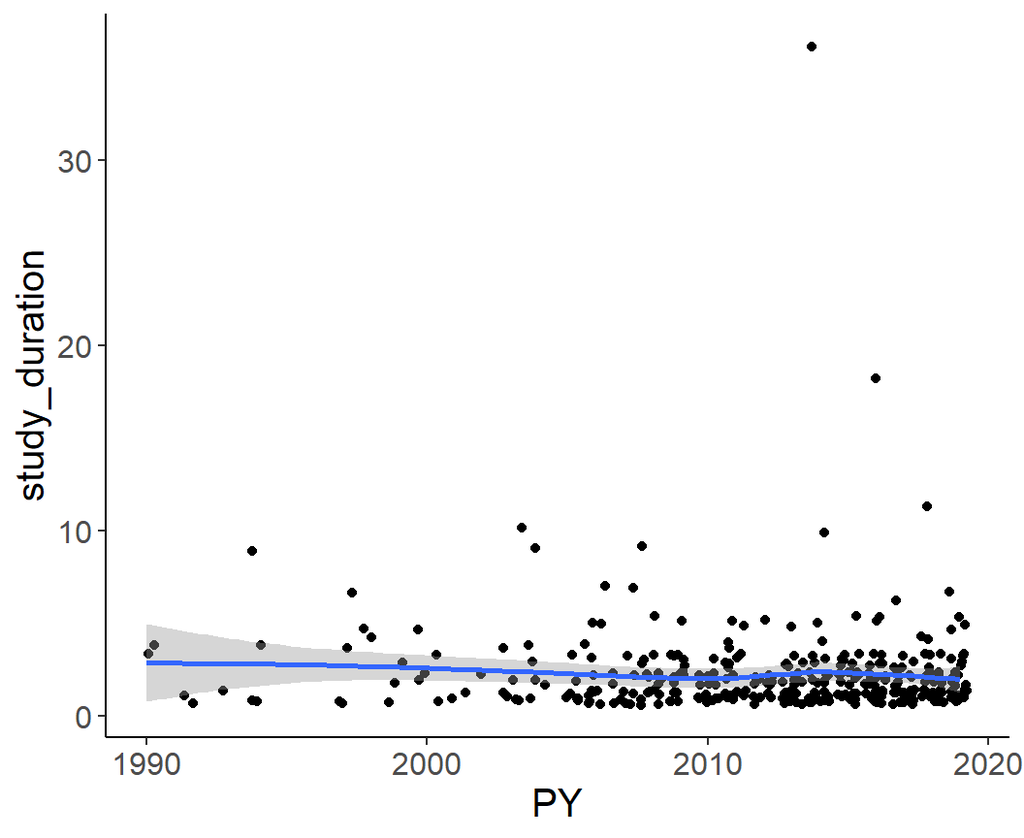

```r
df_relevant %>%
  filter(!is.na(collection_method), confidence_n_bees != "voucher") %>%
  mutate(study_duration = (last_year - first_year)+1, bees_per_year = n_bees_removed/study_duration) %>%
  ggplot(., aes(x = PY, y = study_duration)) +
  geom_jitter() +
  geom_smooth()
```

## 8. Relationship between mean number of bees removed per study by collection type

I dunno, there may be some weak relationship with passive growing over time but I’m not really convinced especially since passive studies don’t really take off until 2010 anyway. I just thought of this and slapped it on here so I haven’t really thought through what is appropriate.

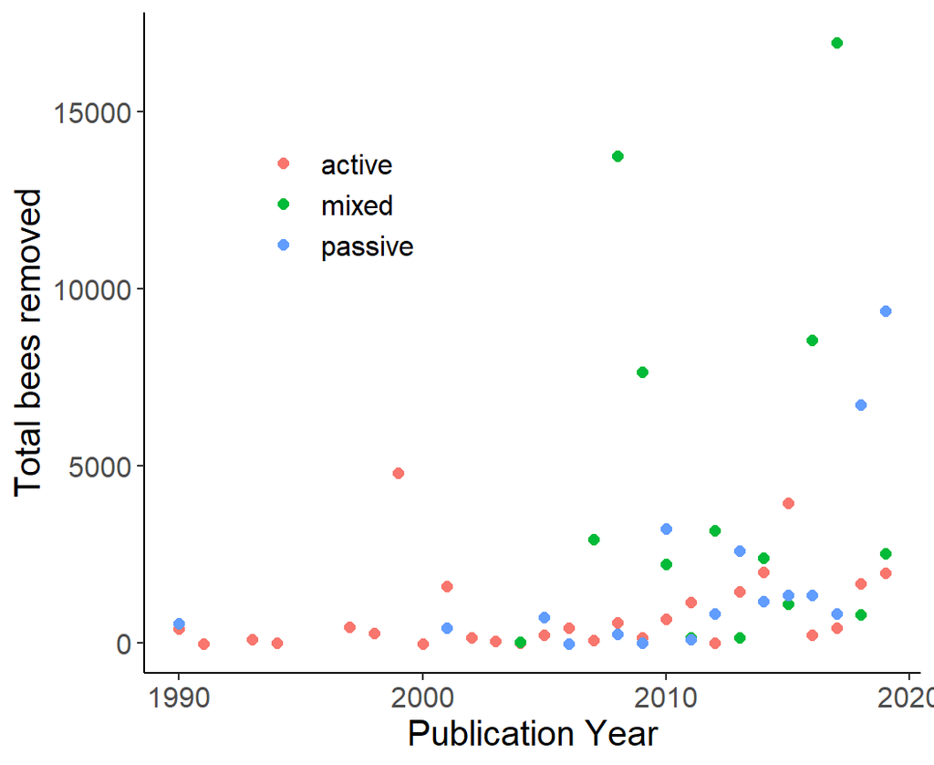

```r
df_relevant %>%
  filter(!is.na(collection_method), confidence_n_bees == "certain") %>%
  # mutate(study_duration = (last_year - first_year)+1, bees_per_year = n_bees_removed/study_duration) %>%
  group_by(PY, collection_method) %>%
  summarise(mean_bees_removed = mean(n_bees_removed, na.rm = T)) %>%
  ggplot(., aes(x = PY, y = mean_bees_removed, color = collection_method)) +
  geom_point(size = 2) +
  #geom_smooth(fill = "grey80", method = "lm", se = F) +
  labs(y = "Total bees removed", x = "Publication Year", color = "") +
  theme(legend.position = c(0.25, 0.75))
```

```r
# PLAYING WITH THE DATA ---------------------------------------------------

# df_relevant %>%
#   filter(!is.na(collection_method), confidence_n_bees != "voucher") %>%
#   mutate(study_duration = (last_year - first_year)+1, bees_per_year = n_bees_removed/study_duration) %>%
#   ggplot(., aes(x = collection_method, y = bees_per_year)) +
#   geom_jitter(width = 0.1, size = 2, alpha = 0.5, aes(color = confidence_n_bees)) +
#   geom_boxplot(alpha = 0.5) +
#   theme_classic()
#
# df_relevant %>%
#   group_by(deposition_info, PY) %>%
#   tally() %>%
#   group_by(PY) %>%
#   mutate(year_pubs = sum(n)) %>%
#   filter(deposition_info == "yes") %>%
#   mutate(percent_reporting = n/year_pubs) %>%
#   ggplot(., aes(x = PY, y = percent_reporting)) +
#   geom_point()

# df_relevant %>%
#   group_by(deposition_info) %>%
#   tally()


# df_so_far %>%
#   group_by(PY) %>%
#   mutate(pubs_that_year = n()) %>%
#   filter(relevant == "yes") %>%
#   group_by(PY) %>%
#   summarise(n = n(), pubs_that_year = first(pubs_that_year), percent_relevant = n/pubs_that_year) %>%
#   ggplot(., aes(x = PY, y = percent_relevant)) +
#   geom_point()

# number of bees per publication year (controlling for study duration) That massive outlier is hte Westphal study...which occurs across five countries, so makes sense there's so many bees
# df_relevant %>%
#   filter(!is.na(collection_method), confidence_n_bees != "voucher") %>%
#   mutate(study_duration = (last_year - first_year)+1, bees_per_year = n_bees_removed/study_duration) %>%
#   group_by(PY) %>%
#   summarise(total_bees_py = sum(bees_per_year, na.rm = T)) %>%
#   ggplot(., aes(x = PY, y = total_bees_py)) +
#   geom_point()
#
# # same as above, exclude westphal
# df_relevant %>%
#   filter(!is.na(collection_method), confidence_n_bees != "voucher", DI != "10.1890/07-1292.1") %>%
#   mutate(study_duration = (last_year - first_year)+1, bees_per_year = n_bees_removed/study_duration) %>%
#   group_by(PY) %>%
#   summarise(total_bees_py = sum(bees_per_year, na.rm = T), n=n(), mean_bpy = mean(bees_per_year, na.rm = TRUE)) %>%
#   # added "n" since we're not done adding the numbers. So this says number of bees collected per year per study (which I guess is just a complex way of calculating mean?)
#   ggplot(., aes(x = PY, y = total_bees_py/n)) +
#   geom_point() +
#   geom_smooth(method = "lm", formula = y ~ x + I(x^2), se = F)

df_relevant %>%
  group_by(PY, collection_method) %>%
  tally() %>%
  ggplot(., aes(x = PY, y = n, color = collection_method)) +
  geom_path() +
  geom_point()



# df_so_far %>%
#   filter(str_detect(follow_up, 'PROBLEM|DISCUSSION')) %>%
#   group_by(gathered_by) %>%
#   tally()
#
# df_so_far %>%
#   filter(str_detect(follow_up, 'DISCUSSION')) %>%
#   select(follow_up)
#


# number of studies per publication year by collection type
df_rel2 <- df_so_far %>%
  filter(relevant %in% c("yes", "no, observational", "no, review or meta-analisis"))

df_rel2 %>%
  group_by(PY, relevant, collection_method) %>%
  tally() %>%
  mutate(study_type = if_else(relevant == "yes", collection_method, relevant)) %>%
  filter(PY < 2012) %>%
  ggplot(., aes(x = PY, y = n, color = study_type)) +
  geom_path()


# what proportion have we reviewed so far

df_all %>%
  mutate(reviewed_yet = if_else(!is.na(relevant), "yes", "no")) %>%
  group_by(PY, reviewed_yet) %>%
  tally() %>%
  pivot_wider(names_from = reviewed_yet, values_from = n) %>%
  mutate(total = no+yes, proportion_reviewed = yes/total) %>%
  ggplot(., aes(x = PY, y = proportion_reviewed)) +
  geom_point()


# df_relevant %>%
#   mutate(lag_time = PY - last_year) %>%
#   ggplot(., aes(x = n_bees_removed/(last_year-first_year), y = lag_time)) +
#   geom_point()


df_so_far %>%
  group_by(gathered_by) %>%
  tally()


df_so_far

df_relevant %>%
  filter(!is.na(collection_method), confidence_n_bees != "voucher") %>%
  mutate(study_duration = (last_year - first_year)+1, bees_per_year = n_bees_removed/study_duration) %>%
  ggplot(., aes(x = PY, y = study_duration)) +
  geom_jitter() +
  geom_smooth()
```